# Analyse des accidents mortels à vélo

Métropole Nice Côte d’Azur, 2005–2024

Auteur·rice

Thelma Panaïotis

Date de publication

21 avril 2026

## Introduction

**Périmètre :** 21 communes de la Métropole Nice Côte d’Azur (Aspremont, Beaulieu-sur-Mer, Cagnes-sur-Mer, Cap-d’Ail, Carros, Castagniers, Colomars, Drap, Èze, Gattières, La Gaude, La Trinité, Le Broc, Nice, Saint-André-de-la-Roche, Saint-Jean-Cap-Ferrat, Saint-Jeannet, Saint-Laurent-du-Var, Tourrette-Levens, Vence, Villefranche-sur-Mer), période 2005–2024.

**ImportantDonnées d’identité**

La BAAC ne contient **aucun nom ni prénom** des victimes. Les informations d’identité proviennent exclusivement de sources externes (presse, archives). Les fiches individuelles en section 4 constituent un document de travail évolutif, alimenté au fil des recherches.

```r
# Table de base : cyclistes décédés avec contexte complet
deces <- usagers_velo |>
  filter(grav == 2) |>
  left_join(caract_velo, by = "Num_Acc") |>
  left_join(
    config_accidents |> select(Num_Acc, configuration, n_total),
    by = "Num_Acc"
  ) |>
  left_join(lieux_velo, by = "Num_Acc") |>
  left_join(communes, by = c("com" = "code_insee")) |>   # ← ajout
  mutate(
    age       = an - an_nais,
    age       = if_else(age < 0 | age > 110, NA_real_, age),
    adr       = iconv(adr, from = "latin1", to = "UTF-8"),
    adr       = if_else(is.na(adr), "", adr),
    velo_seul = configuration == "Vélo seul"
  ) |>
  arrange(desc(an), desc(mois), desc(jour))

n_accidents_mortels <- n_distinct(deces$Num_Acc)
n_tues              <- nrow(deces)
n_velo_seul         <- sum(deces$velo_seul, na.rm = TRUE)
```

Entre 2005 et 2024, **27 accidents mortels** impliquant un vélo ont été enregistrés sur les 21 communes de la Métropole Nice Côte d’Azur, causant **27 décès de cyclistes**, dont **9 en accidents “vélo seul”** (sans tiers impliqué).

# 1. Vue d’ensemble des accidents mortels

## Tableau récapitulatif

```r
deces |>
  mutate(date = paste(jour, mois, an, sep = "/")) |>
  select(Num_Acc, date, hrmn, nom_commune, adr, configuration, sexe_label, age) |>
  arrange(Num_Acc) |>
  gt() |>
  tab_header(
    title    = "Accidents mortels à vélo — Métropole Nice Côte d'Azur",
    subtitle = "2005–2024 · Source : BAAC"
  ) |>
  cols_label(
    Num_Acc       = "N° Accident",
    date          = "Date",
    hrmn          = "Heure",
    nom_commune   = "Commune",
    adr           = "Adresse",
    configuration = "Configuration",
    sexe_label    = "Sexe",
    age           = "Âge"
  ) |>
  tab_style(
    style     = cell_fill(color = "#fde8e8"),
    locations = cells_body(rows = configuration == "Vélo seul")
  ) |>
  tab_footnote("Lignes surlignées = accidents sans tiers (vélo seul).")
```

Accidents mortels à vélo — Métropole Nice Côte d'Azur

2005–2024 · Source : BAAC

| N° Accident | Date | Heure | Commune | Adresse | Configuration | Sexe | Âge |
| --- | --- | --- | --- | --- | --- | --- | --- |
| 200500039455 | 12/6/2005 | 08:45 | Aspremont |  | Vélo vs voiture | Homme | 26 |
| 200500050470 | 12/8/2005 | 12:05 | Nice | 0, ANGLAIS (A PARTIR DU | Vélo vs voiture | Homme | 83 |
| 200600011271 | 5/3/2006 | 18:45 | Nice | 0, TERRON (CH. DE) | Vélo seul | Femme | 65 |
| 200600046326 | 3/8/2006 | 10:30 | Le Broc |  | Vélo seul | Femme | 50 |
| 200700041904 | 26/7/2007 | 14:20 | Nice | 0, CORNIGLION MOLINIER ( | Vélo vs poids lourd | Homme | 74 |
| 200900020027 | 7/2/2009 | 16:15 | Gattières |  | Vélo vs poids lourd | Homme | 30 |
| 201000016267 | 18/1/2010 | 16:55 | Nice | 0, VERANY (BD J.B.) | Vélo vs poids lourd | Femme | 37 |
| 201000016733 | 18/6/2010 | 17:55 | Nice | 21, CAPPATTI F.L. (RUE) | Vélo seul | Homme | 47 |
| 201100015801 | 18/4/2011 | 17:00 | Nice | 0, RD 6202 | Vélo seul | Femme | 61 |
| 201200011446 | 8/6/2012 | 09:50 | Nice | 0, COLOMARS (ROUTE DE) | Vélo vs poids lourd | Homme | 31 |
| 201300011100 | 11/7/2013 | 16:30 | Nice | 0, NAPOLEON III (PONT) | Vélo vs voiture | Homme | 88 |
| 201300011321 | 2/11/2013 | 08:45 | Nice | 52, CARNOT (BD) | Vélo seul | Homme | 61 |
| 201500007802 | 28/8/2015 | 09:45 | La Trinité | Rond point de l'oli | Vélo vs poids lourd | Homme | 62 |
| 201500007839 | 6/9/2015 | 00:45 | La Gaude | Route de St Laurent | Vélo vs voiture | Homme | 16 |
| 201600010985 | 3/3/2016 | 09:00 | Nice | 29, LYAUTEY (AV. DU MAL) | Vélo seul | Homme | 69 |
| 201700006225 | 31/5/2017 | 10:20 | Villefranche-sur-Mer | CORNE D OR (BOULEVARD DE | Vélo seul | Homme | 67 |
| 201800003732 | 30/9/2018 | 11:20 | La Gaude | 8324 route de Cagnes | Vélo seul | Homme | 62 |
| 201800005861 | 4/12/2018 | 12:15 | Nice | ANGLAIS (DU Nø 1 AU Nø 4 | Vélo vs 2RM | Femme | 67 |
| 201800013738 | 6/3/2018 | 11:45 | Cap-d'Ail | 60 avenue du 3 septembre | Autre configuration | Homme | 62 |
| 201900010384 | 19/4/2019 | 17:25 | Cagnes-sur-Mer | GARE AVENUE DE LA | Vélo vs poids lourd | Homme | 83 |
| 201900019321 | 19/4/2019 | 11:35 | Vence | 1325 Route de Saint-Jeannet | Vélo seul | Homme | 86 |
| 202000032237 | 4/7/2020 | 01:30 | Nice | RISSO (BD) | Vélo vs 2RM | Homme | 32 |
| 202100036505 | 4/06/2021 | 13:20 | Carros | 1104 Route de Gattières | Vélo vs voiture | Homme | 27 |
| 202100038386 | 24/05/2021 | 19:29 | Nice | ANGLAIS (A PARTIR DU N° 351) | Autre configuration | Homme | 23 |
| 202200009470 | 18/03/2022 | 08:00 | Cagnes-sur-Mer | CANNES AVENUE DE (RN7) | Vélo vs poids lourd | Homme | 22 |
| 202200034765 | 25/08/2022 | 16:45 | Vence | Chemin des Anciens Combattants d Afrique du Nord | Vélo vs voiture | Femme | 16 |
| 202300045287 | 1/11/2023 | 13:54 | Nice | ANGLAIS (DU N° 265 AU N° 350) | Vélo vs voiture | Homme | 79 |

Lignes surlignées = accidents sans tiers (vélo seul).

## Cartographie (2019–2024)

```r
deces_geo <- deces |>
  filter(!is.na(lat), !is.na(long), lat != 0, long != 0)

if (nrow(deces_geo) > 0) {
  leaflet(deces_geo) |>
    addTiles() |>
    addCircleMarkers(
      lng         = ~long,
      lat         = ~lat,
      radius      = 8,
      color       = ~if_else(velo_seul, col_orange, col_navy),
      stroke      = TRUE,
      weight      = 2,
      fillOpacity = 0.8,
      popup = ~paste0(
        "<b>Commune :</b> ", com, "<br>",
        "<b>Année :</b> ", an, "<br>",
        "<b>Date :</b> ", jour, "/", mois, "<br>",
        "<b>Heure :</b> ", hrmn, "<br>",
        "<b>Configuration :</b> ", configuration, "<br>",
        "<b>Adresse :</b> ", adr, "<br>",
        "<b>Sexe :</b> ", sexe_label,
        " | <b>Âge :</b> ",
        if_else(is.na(age), "?", as.character(round(age))), " ans"
      )
    ) |>
    addLegend(
      position = "bottomright",
      colors   = c(col_navy, col_orange),
      labels   = c("Avec tiers", "Vélo seul"),
      title    = "Configuration"
    )
} else {
  cat("Pas de coordonnées GPS disponibles (données géolocalisées uniquement à partir de 2019).\n")
}
```

[interactive chart not shown]

# 2. Caractéristiques des accidents mortels

## Configuration et évolution

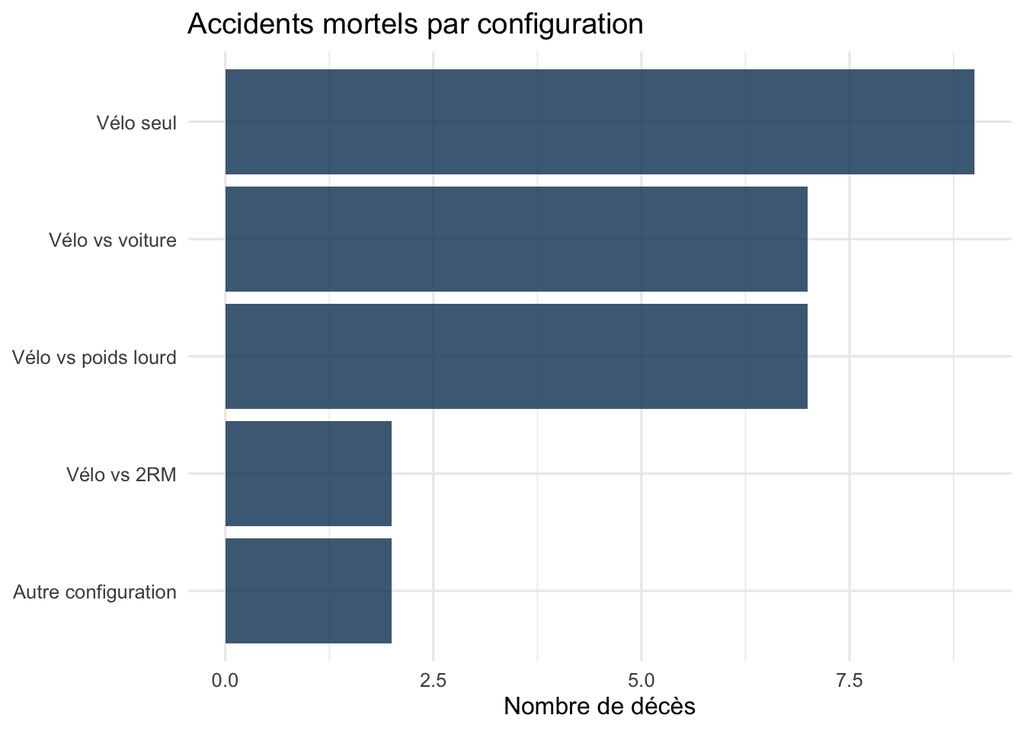

```r
deces |>
  count(configuration, sort = TRUE) |>
  mutate(configuration = fct_reorder(configuration, n)) |>
  ggplot(aes(x = configuration, y = n)) +
  geom_col(fill = col_navy, alpha = 0.8) +
  coord_flip() +
  labs(
    title = "Accidents mortels par configuration",
    x     = NULL,
    y     = "Nombre de décès"
  )
```

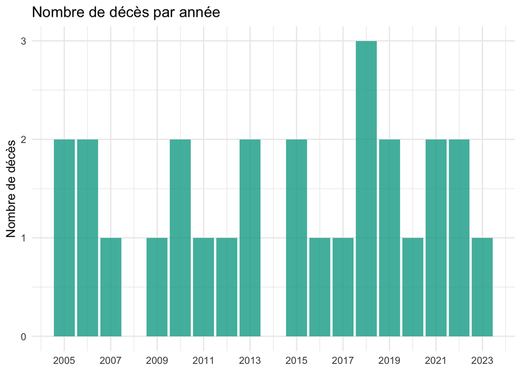

```r
deces |>
  count(an) |>
  ggplot(aes(x = an, y = n)) +
  geom_col(fill = col_teal, alpha = 0.8) +
  scale_x_continuous(breaks = seq(2005, 2024, 2)) +
  labs(
    title = "Nombre de décès par année",
    x     = NULL,
    y     = "Nombre de décès"
  )
```

## Profil des victimes

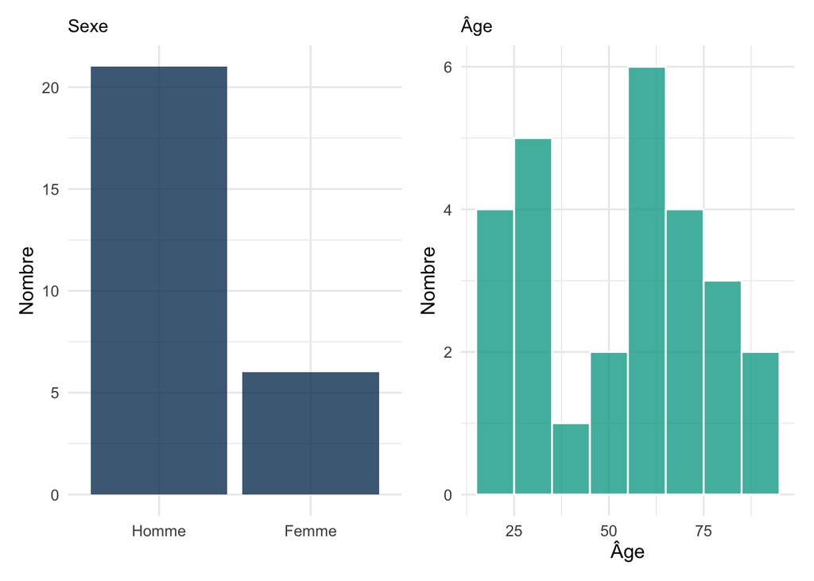

```r
p_sexe <- deces |>
  count(sexe_label) |>
  ggplot(aes(x = sexe_label, y = n)) +
  geom_col(fill = col_navy, alpha = 0.8) +
  labs(title = "Sexe", x = NULL, y = "Nombre") +
  theme(plot.title = element_text(size = 11))

p_age <- deces |>
  filter(!is.na(age)) |>
  ggplot(aes(x = age)) +
  geom_histogram(binwidth = 10, fill = col_teal, alpha = 0.8, colour = "white") +
  labs(title = "Âge", x = "Âge", y = "Nombre") +
  theme(plot.title = element_text(size = 11))

p_sexe + p_age
```

## Circonstances

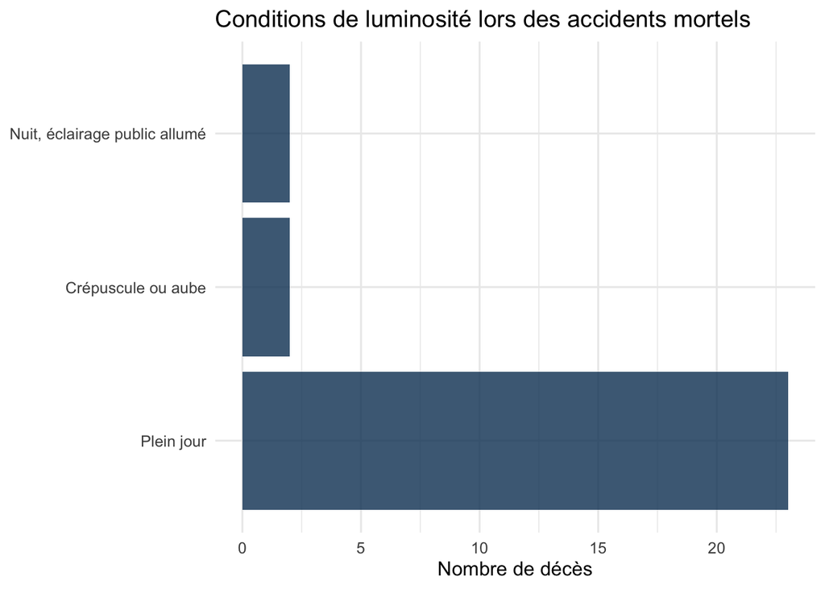

```r
deces |>
  count(lum_label) |>
  mutate(lum_label = fct_reorder(lum_label, n, .desc = TRUE)) |>
  ggplot(aes(x = lum_label, y = n)) +
  geom_col(fill = col_navy, alpha = 0.8) +
  coord_flip() +
  labs(
    title = "Conditions de luminosité lors des accidents mortels",
    x     = NULL,
    y     = "Nombre de décès"
  )
```

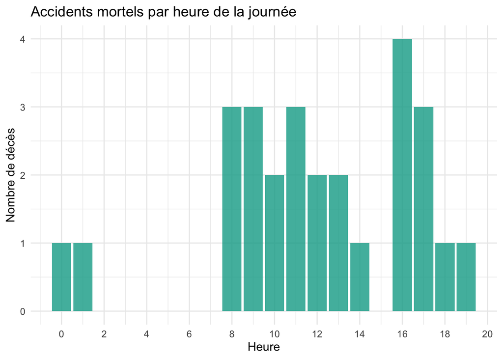

```r
deces |>
  filter(!is.na(hrmn), str_detect(hrmn, "^\\d{2}:\\d{2}$")) |>
  mutate(heure = as.integer(substr(hrmn, 1, 2))) |>
  count(heure) |>
  ggplot(aes(x = heure, y = n)) +
  geom_col(fill = col_teal, alpha = 0.8) +
  scale_x_continuous(breaks = seq(0, 23, 2)) +
  labs(
    title = "Accidents mortels par heure de la journée",
    x     = "Heure",
    y     = "Nombre de décès"
  )
```

# 3. Focus : accidents mortels “vélo seul”

```r
# Sous-table pour les analyses "vélo seul"
deces_vs <- deces |>
  filter(velo_seul) |>
  left_join(
    vehicules_velo |> select(Num_Acc, num_veh, obs),
    by = c("Num_Acc", "num_veh")
  )
```

## Profil des victimes

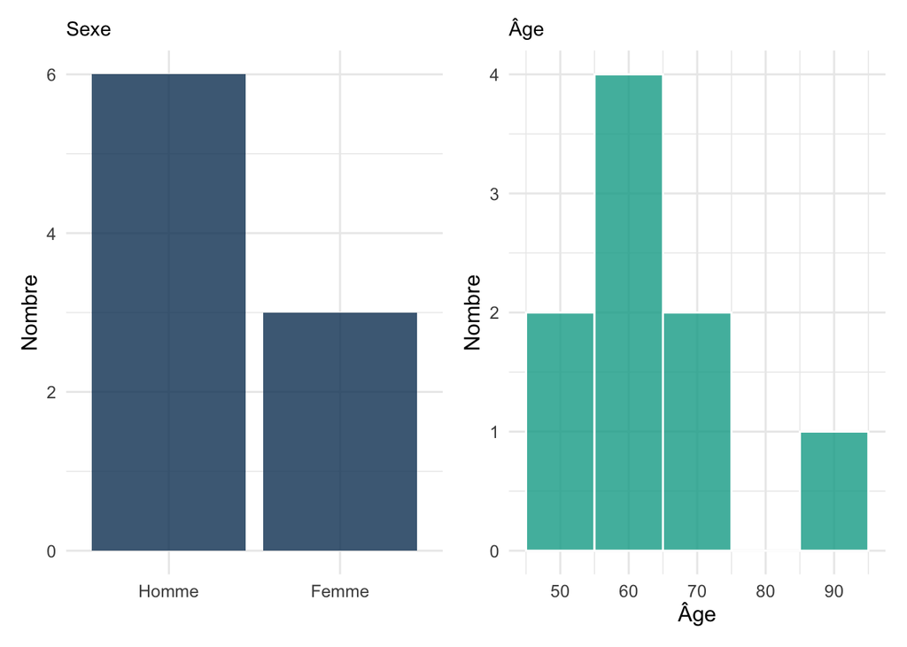

```r
p1 <- deces_vs |>
  count(sexe_label) |>
  ggplot(aes(x = sexe_label, y = n)) +
  geom_col(fill = col_navy, alpha = 0.8) +
  labs(title = "Sexe", x = NULL, y = "Nombre") +
  theme(plot.title = element_text(size = 11))

p2 <- deces_vs |>
  filter(!is.na(age)) |>
  ggplot(aes(x = age)) +
  geom_histogram(binwidth = 10, fill = col_teal, alpha = 0.8, colour = "white") +
  labs(title = "Âge", x = "Âge", y = "Nombre") +
  theme(plot.title = element_text(size = 11))

p1 + p2
```

## Conditions d’éclairage et météo

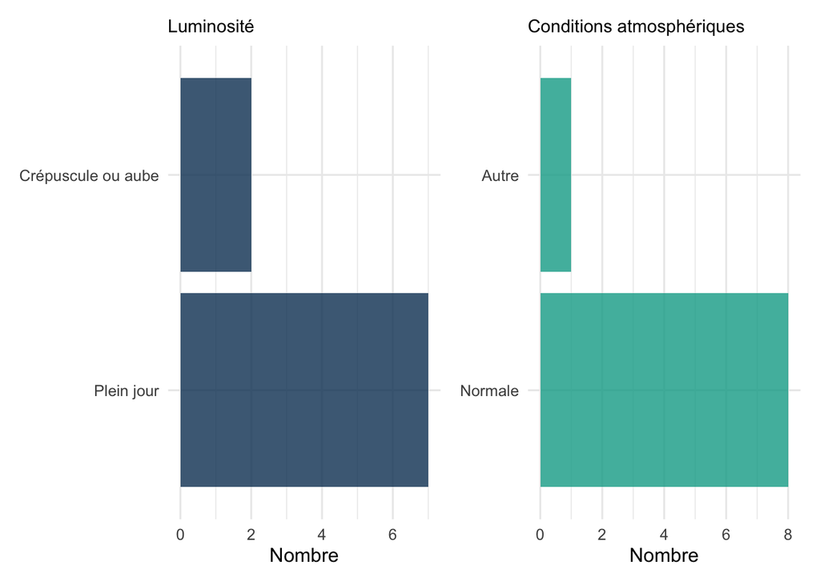

```r
p1 <- deces_vs |>
  count(lum_label) |>
  mutate(lum_label = fct_reorder(lum_label, n, .desc = TRUE)) |>
  ggplot(aes(x = lum_label, y = n)) +
  geom_col(fill = col_navy, alpha = 0.8) +
  coord_flip() +
  labs(title = "Luminosité", x = NULL, y = "Nombre") +
  theme(plot.title = element_text(size = 11))

p2 <- deces_vs |>
  count(atm_label) |>
  mutate(atm_label = fct_reorder(atm_label, n, .desc = TRUE)) |>
  ggplot(aes(x = atm_label, y = n)) +
  geom_col(fill = col_teal, alpha = 0.8) +
  coord_flip() +
  labs(title = "Conditions atmosphériques", x = NULL, y = "Nombre") +
  theme(plot.title = element_text(size = 11))

p1 + p2
```

## Infrastructure et type de voie

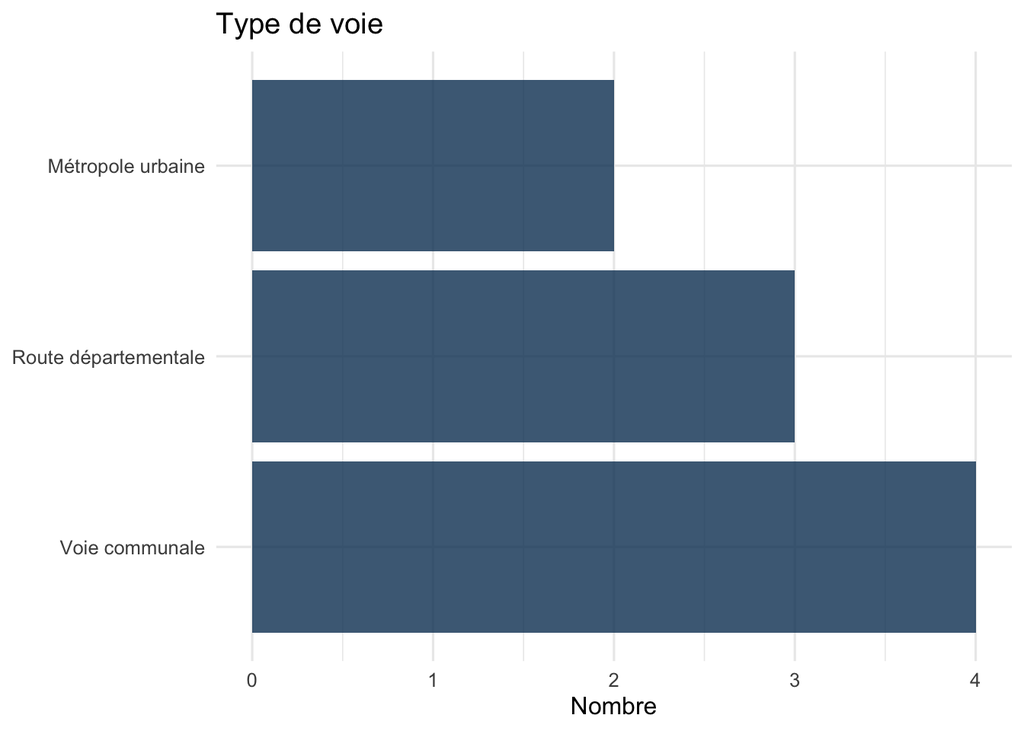

```r
deces_vs |>
  mutate(
    catr_label = case_when(
      catr == 1 ~ "Autoroute",
      catr == 2 ~ "Route nationale",
      catr == 3 ~ "Route départementale",
      catr == 4 ~ "Voie communale",
      catr == 5 ~ "Hors réseau public",
      catr == 6 ~ "Parking",
      catr == 7 ~ "Métropole urbaine",
      catr == 9 ~ "Autre",
      TRUE      ~ "Non renseigné"
    )
  ) |>
  count(catr_label) |>
  mutate(catr_label = fct_reorder(catr_label, n, .desc = TRUE)) |>
  ggplot(aes(x = catr_label, y = n)) +
  geom_col(fill = col_navy, alpha = 0.8) +
  coord_flip() +
  labs(title = "Type de voie", x = NULL, y = "Nombre")
```

```r
deces_vs |>
  mutate(
    vosp_label = case_when(
      vosp == 0 | is.na(vosp) ~ "Pas de voie réservée",
      vosp == 1               ~ "Piste cyclable",
      vosp == 2               ~ "Bande cyclable",
      vosp == 3               ~ "Voie réservée",
      TRUE                    ~ "Non renseigné"
    ),
    surf_label = case_when(
      surf == 1 ~ "Normale",
      surf == 2 ~ "Mouillée",
      surf == 3 ~ "Flaques",
      surf == 4 ~ "Inondée",
      surf == 5 ~ "Enneigée",
      surf == 6 ~ "Boue",
      surf == 7 ~ "Verglacée",
      surf == 8 ~ "Corps gras",
      surf == 9 ~ "Autre",
      TRUE      ~ "Non renseigné"
    )
  ) |>
  select(Num_Acc, vosp_label, surf_label) |>
  gt() |>
  tab_header(title = "Infrastructure et surface — accidents vélo seul") |>
  cols_label(
    Num_Acc    = "N° Accident",
    vosp_label = "Voie réservée",
    surf_label = "État surface"
  )
```

Infrastructure et surface — accidents vélo seul

| N° Accident | Voie réservée | État surface |
| --- | --- | --- |
| 201900019321 | Bande cyclable | Normale |
| 201800003732 | Pas de voie réservée | Normale |
| 201700006225 | Pas de voie réservée | Normale |
| 201600010985 | Piste cyclable | Normale |
| 201300011321 | Pas de voie réservée | Normale |
| 201100015801 | Pas de voie réservée | Normale |
| 201000016733 | Pas de voie réservée | Normale |
| 200600046326 | Pas de voie réservée | Normale |
| 200600011271 | Pas de voie réservée | Normale |

## Obstacle heurté

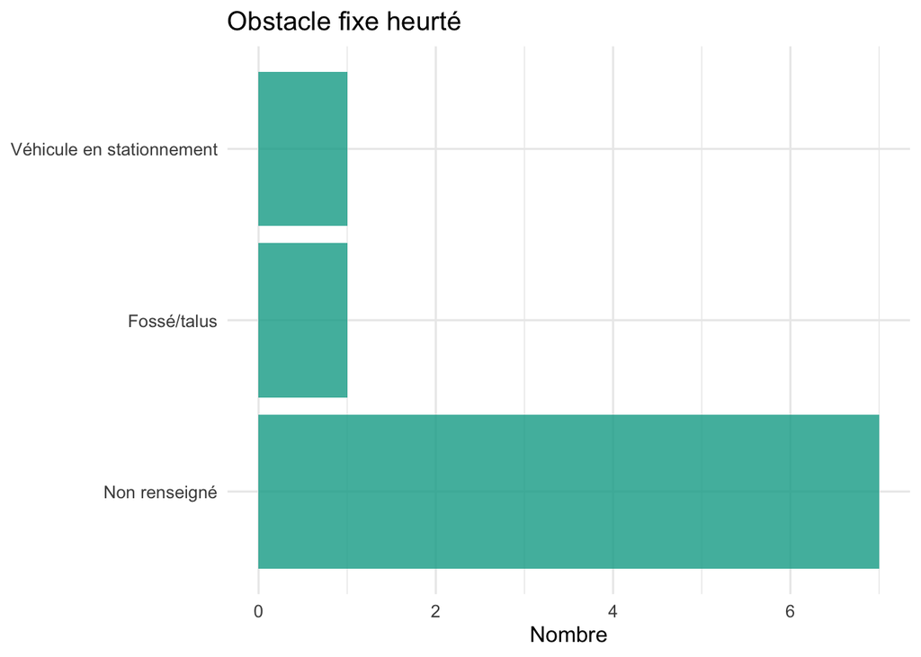

```r
deces_vs |>
  mutate(
    obs_label = case_when(
      obs == 0 | is.na(obs) ~ "Sans objet",
      obs == 1  ~ "Véhicule en stationnement",
      obs == 2  ~ "Arbre",
      obs == 3  ~ "Glissière métallique",
      obs == 4  ~ "Glissière béton",
      obs == 5  ~ "Autre glissière",
      obs == 6  ~ "Bâtiment/mur/pile",
      obs == 7  ~ "Signalisation",
      obs == 8  ~ "Poteau",
      obs == 9  ~ "Mobilier urbain",
      obs == 10 ~ "Parapet",
      obs == 11 ~ "Ilot/refuge/borne",
      obs == 12 ~ "Bordure trottoir",
      obs == 13 ~ "Fossé/talus",
      obs == 14 ~ "Autre obstacle chaussée",
      obs == 15 ~ "Autre obstacle trottoir",
      obs == 16 ~ "Sortie chaussée sans obstacle",
      obs == 17 ~ "Buse/aqueduc",
      TRUE      ~ "Non renseigné"
    )
  ) |>
  count(obs_label) |>
  mutate(obs_label = fct_reorder(obs_label, n, .desc = TRUE)) |>
  ggplot(aes(x = obs_label, y = n)) +
  geom_col(fill = col_teal, alpha = 0.8) +
  coord_flip() +
  labs(title = "Obstacle fixe heurté", x = NULL, y = "Nombre")
```

**AvertissementHypothèses à investiguer**

Les accidents “vélo seul” peuvent résulter de :

- **Problèmes d’infrastructure** : nid de poule, rail de tram, bordure, obstacle non signalé
- **Perte de contrôle** : descente, virage serré, vitesse excessive
- **Collision avec élément fixe** : poteau, arbre, mobilier urbain
- **Malaise médical** : arrêt cardiaque, syncope (notamment pour les victimes âgées)
- **Tiers non identifié** : le véhicule impliqué a pris la fuite et n’a pas été enregistré

La documentation presse et l’inspection terrain permettront de distinguer ces causes et d’identifier les éventuelles responsabilités (infrastructure défaillante vs comportement).

# 4. Fiches individuelles

Ces fiches sont alimentées manuellement au fil des recherches. Les champs BAAC sont pré-remplis automatiquement ; les champs identité et sources sont à compléter dans `fiches_manuelles` ci-dessous.

**Sources à consulter :**

- **Nice-Matin numérique** (~2010–2024) : abonnement ou accès médiathèque
- **Nice-Matin papier** (2005–2012) : médiathèque Louis Nucéra, fonds de presse locale
- **France 3 Côte d’Azur** : archives vidéo/web pour les cas médiatisés
- **Zotero** : référencer chaque article trouvé avec la clé de collection `nice-velo-deces`

```r
## ── À COMPLÉTER AU FIL DES RECHERCHES ──────────────────────────────────────
## statut_recherche : "Identifié" | "Partiellement identifié" | "Non trouvé" | "À investiguer"
fiches_manuelles <- tribble(
  ~Num_Acc,       ~prenom, ~nom_famille, ~statut_recherche,         ~sources_zotero,              ~notes,

  # Cas 1 — Aspremont, 12/06/2005, H, 26 ans, vélo vs voiture
  "200500039455", NA, NA, "Non trouvé", NA,
    "Aucune trace en ligne. Archives Nice-Matin papier à consulter (médiathèque Louis Nucéra, juin 2005).",

  # Cas 2 — Nice, Prom des Anglais, 12/08/2005, H, 83 ans, vélo vs voiture
  "200500050470", NA, NA, "Non trouvé", NA,
    "Aucune trace en ligne. Archives Nice-Matin papier à consulter (août 2005). Victime âgée de 83 ans — malaise médical possible à investiguer.",

  # Cas 3 — Nice, ch. de Terron, 05/03/2006, F, 65 ans, vélo seul
  "200600011271", NA, NA, "Non trouvé", NA,
    "Aucune trace en ligne. Archives Nice-Matin papier (mars 2006). Vélo seul, femme 65 ans — chute ou malaise à investiguer.",

  # Cas 4 — Le Broc, 03/08/2006, F, 50 ans, vélo seul
  "200600046326", NA, NA, "Non trouvé", NA,
    "Aucune trace en ligne. Archives Nice-Matin papier (août 2006). Vélo seul en zone rurale (Le Broc) — infrastructure ou descente à investiguer.",

  # Cas 5 — Nice, Corniglion Molinier, 26/07/2007, H, 74 ans, vélo vs poids lourd
  "200700041904", NA, NA, "Non trouvé", NA,
    "Aucune trace en ligne. Archives Nice-Matin papier (juillet 2007). Poids lourd — angle mort probable.",

  # Cas 6 — Gattières, 07/02/2009, H, 30 ans, vélo vs poids lourd
  "200900020027", NA, NA, "Non trouvé", NA,
    "Aucune trace en ligne. Archives Nice-Matin papier (février 2009). Route rurale, poids lourd.",

  # Cas 7 — Nice, bd J.B. Verany, 18/01/2010, F, 37 ans, vélo vs poids lourd
  "201000016267", NA, NA, "Non trouvé", NA,
    "Aucune trace en ligne. Archives Nice-Matin papier (janvier 2010). Femme 37 ans, poids lourd en ville.",

  # Cas 8 — Nice, rue Cappatti, 18/06/2010, H, 47 ans, vélo seul
  "201000016733", NA, NA, "Non trouvé", NA,
    "Aucune trace en ligne. Archives Nice-Matin papier (juin 2010). Vélo seul, rue Cappatti.",

  # Cas 9 — Nice, RD 6202, 18/04/2011, F, 61 ans, vélo seul
  "201100015801", NA, NA, "Non trouvé", NA,
    "Aucune trace en ligne. Archives Nice-Matin papier (avril 2011). Vélo seul sur route départementale — infrastructure à investiguer.",

  # Cas 10 — Nice, route de Colomars, 08/06/2012, H, 31 ans, vélo vs poids lourd
  "201200011446", NA, NA, "Non trouvé", NA,
    "Aucune trace en ligne. Archives Nice-Matin papier (juin 2012). Poids lourd, route de Colomars.",

  # Cas 11 — Nice, pont Napoléon III, 11/07/2013, H, 88 ans, vélo vs voiture
  "201300011100", NA, NA, "Non trouvé", NA,
    "Aucune trace en ligne. Victime âgée de 88 ans — malaise médical possible. Archives Nice-Matin (juillet 2013).",

  # Cas 12 — Nice, bd Carnot, 02/11/2013, H, 61 ans, vélo seul
  "201300011321", NA, NA, "Non trouvé", NA,
    "Aucune trace en ligne. Vélo seul, boulevard Carnot, 8h45. Archives Nice-Matin (novembre 2013).",

  # Cas 13 — La Trinité, rond-point de l'Oli, 28/08/2015, H, 62 ans, vélo vs poids lourd
  "201500007802", NA, NA, "Non trouvé", NA,
    "Aucune trace en ligne. Rond-point — angle mort classique avec poids lourd. Archives Nice-Matin (août 2015).",

  # Cas 14 — La Gaude, route de St Laurent, 06/09/2015, H, 16 ans, vélo vs voiture
  "201500007839", NA, NA, "Non trouvé", NA,
    "Aucune trace en ligne. Victime de 16 ans, nuit (00h45) — possible sortie nocturne. Archives Nice-Matin (septembre 2015). Cas à prioriser.",

  # Cas 15 — Nice, av. du Mal Lyautey, 03/03/2016, H, 69 ans, vélo seul
  "201600010985", NA, NA, "Non trouvé", NA,
    "Aucune trace en ligne. Vélo seul 9h00, avenue Lyautey. Archives Nice-Matin (mars 2016).",

  # Cas 16 — Villefranche, bvd de la Corne d'Or, 31/05/2017, H, 67 ans, vélo seul
  "201700006225", NA, NA, "Non trouvé", NA,
    "Aucune trace en ligne. Vélo seul, bord de mer (bd de la Corne d'Or). Descente ou infrastructure à investiguer. Archives Nice-Matin (mai 2017).",

  # Cas 17 — La Gaude, route de Cagnes, 30/09/2018, H, 62 ans, vélo seul
  "201800003732", NA, NA, "Non trouvé", NA,
    "Aucune trace en ligne. Vélo seul, route rurale La Gaude. Archives Nice-Matin (septembre 2018).",

  # Cas 18 — Nice, Prom des Anglais, 04/12/2018, F, 67 ans, vélo vs 2RM
  "201800005861", NA, NA, "Non trouvé", NA,
    "Aucune trace en ligne. Collision vélo/2RM sur la Prom, midi. Archives Nice-Matin (décembre 2018).",

  # Cas 19 — Cap-d'Ail, av. du 3 septembre, 06/03/2018, H, 62 ans, autre configuration
  "201800013738", NA, NA, "Non trouvé", NA,
    "Aucune trace en ligne. Configuration atypique ('autre') à préciser. Archives Nice-Matin (mars 2018).",

  # Cas 20 — Cagnes-sur-Mer, avenue de la Gare, 19/04/2019, H, 83 ans, vélo vs poids lourd
  "201900010384", NA, NA, "Partiellement identifié", "francebleu-2019-04-19",
    "Cycliste percuté par un poids lourd route de Cannes à hauteur du domaine du Loup, Cagnes-sur-Mer. Pompiers n'ont pas réussi à le réanimer. Victime âgée de 83 ans. Source : France Bleu Azur (date à confirmer — article daté mars 2022 mais correspond à cet accident ou à un autre sur le même site).",

  # Cas 21 — Vence, route de Saint-Jeannet, 19/04/2019, H, 86 ans, vélo seul
  "201900019321", NA, NA, "Non trouvé", NA,
    "Aucune trace en ligne. Vélo seul, route rurale Vence. Victime âgée de 86 ans — malaise médical très probable. Rechercher Nice-Matin avril 2019.",

  # Cas 22 — Nice, bd Risso, 04/07/2020, H, 32 ans, vélo vs 2RM
  "202000032237", NA, NA, "Non trouvé", NA,
    "Aucune trace en ligne. Collision vélo/2RM, nuit (01h30), bd Risso. Profil jeune (32 ans), nuit estivale. Rechercher Nice-Matin juillet 2020.",

  # Cas 23 — Carros, route de Gattières, 04/06/2021, H, 27 ans, vélo vs voiture
  "202100036505", NA, NA, "Non trouvé", NA,
    "Aucune trace en ligne (encodage latin1 dans l'adresse : 'Gattières'). Route rurale Carros–Gattières. Rechercher Nice-Matin juin 2021.",

  # Cas 24 — Nice, Prom des Anglais, 24/05/2021, H, 23 ans, autre configuration
  "202100038386", NA, NA, "Non trouvé", NA,
    "Aucune trace en ligne. Configuration atypique sur la Prom. Victime jeune (23 ans). Rechercher Nice-Matin mai 2021.",

  # Cas 25 — Cagnes-sur-Mer, avenue de Cannes RN7, 18/03/2022, H, 22 ans, vélo vs poids lourd
  "202200009470", NA, NA, "Partiellement identifié", "francebleu-2022-03-18",
    "Cycliste de 22 ans percuté par un poids lourd route de Cannes à hauteur du Domaine du Loup, Cagnes-sur-Mer. Réanimation impossible sur place. Selon un article de suivi, il circulait sur une piste cyclable et aurait fait un léger écart avant de chuter sur la chaussée. Source : France Bleu Azur 18/03/2022.",

  # Cas 26 — Vence, chemin Anciens Combattants, 25/08/2022, F, 16 ans, vélo vs voiture
  "202200034765", NA, NA, "Non trouvé", NA,
    "Aucune trace en ligne. Victime de 16 ans, femme — cas à prioriser. Route rurale Vence. Rechercher Nice-Matin août 2022.",

  # Cas 27 — Nice, Prom des Anglais, 01/11/2023, H, 79 ans, vélo vs voiture
  "202300045287", NA, NA, "Partiellement identifié", "francebleu-2023-11-01, ici-2023-11-01",
    "Collision voiture/vélo le 01/11/2023 vers 14h15 sur la Prom des Anglais en face du Casino Ferber. Homme ~70-79 ans en arrêt cardio-respiratoire à l'arrivée des secours, transporté à Pasteur 2. Articles initiaux : 'grièvement blessé' — décès probablement survenu après hospitalisation.",
)

## ────────────────────────────────────────────────────────────────────────────
```

## Cas 01 — — Nice

**NoteStatut : Partiellement identifié**

| Champ | Valeur |
| --- | --- |
| **ID accident** | `202300045287` |
| **Date** | 1/11/2023 |
| **Heure** | 13:54 |
| **Commune** | Nice |
| **Adresse** | ANGLAIS (DU N° 265 AU N° 350) |
| **GPS** | 43.67538, 7.22778 |
| **Sexe** | Homme |
| **Âge estimé** | 79 ans |
| **Configuration** | Vélo vs voiture |
| **Luminosité** | Plein jour |
| **Météo** | Normale |
| **Type collision** | Trois véhicules et + - en chaîne |

**Sources Zotero :** francebleu-2023-11-01, ici-2023-11-01

**Notes d’investigation :** Collision voiture/vélo le 01/11/2023 vers 14h15 sur la Prom des Anglais en face du Casino Ferber. Homme ~70-79 ans en arrêt cardio-respiratoire à l’arrivée des secours, transporté à Pasteur 2. Articles initiaux : ‘grièvement blessé’ — décès probablement survenu après hospitalisation.

## Cas 02 — — Vence

**AvertissementStatut : Non trouvé**

| Champ | Valeur |
| --- | --- |
| **ID accident** | `202200034765` |
| **Date** | 25/08/2022 |
| **Heure** | 16:45 |
| **Commune** | Vence |
| **Adresse** | Chemin des Anciens Combattants d Afrique du Nord |
| **GPS** | 43.72444, 7.08964 |
| **Sexe** | Femme |
| **Âge estimé** | 16 ans |
| **Configuration** | Vélo vs voiture |
| **Luminosité** | Plein jour |
| **Météo** | Normale |
| **Type collision** | Deux véhicules - par le côté |

**Sources Zotero :** Aucune source trouvée

**Notes d’investigation :** Aucune trace en ligne. Victime de 16 ans, femme — cas à prioriser. Route rurale Vence. Rechercher Nice-Matin août 2022.

## Cas 03 — — Cagnes-sur-Mer

**NoteStatut : Partiellement identifié**

| Champ | Valeur |
| --- | --- |
| **ID accident** | `202200009470` |
| **Date** | 18/03/2022 |
| **Heure** | 08:00 |
| **Commune** | Cagnes-sur-Mer |
| **Adresse** | CANNES AVENUE DE (RN7) |
| **GPS** | 43.65055, 7.14122 |
| **Sexe** | Homme |
| **Âge estimé** | 22 ans |
| **Configuration** | Vélo vs poids lourd |
| **Luminosité** | Plein jour |
| **Météo** | Normale |
| **Type collision** | Deux véhicules - par le côté |

**Sources Zotero :** francebleu-2022-03-18

**Notes d’investigation :** Cycliste de 22 ans percuté par un poids lourd route de Cannes à hauteur du Domaine du Loup, Cagnes-sur-Mer. Réanimation impossible sur place. Selon un article de suivi, il circulait sur une piste cyclable et aurait fait un léger écart avant de chuter sur la chaussée. Source : France Bleu Azur 18/03/2022.

## Cas 04 — — Carros

**AvertissementStatut : Non trouvé**

| Champ | Valeur |
| --- | --- |
| **ID accident** | `202100036505` |
| **Date** | 4/06/2021 |
| **Heure** | 13:20 |
| **Commune** | Carros |
| **Adresse** | 1104 Route de GattiÃ¨res |
| **GPS** | 43.78418, 7.17723 |
| **Sexe** | Homme |
| **Âge estimé** | 27 ans |
| **Configuration** | Vélo vs voiture |
| **Luminosité** | Plein jour |
| **Météo** | Normale |
| **Type collision** | Deux véhicules - frontale |

**Sources Zotero :** Aucune source trouvée

**Notes d’investigation :** Aucune trace en ligne (encodage latin1 dans l’adresse : ‘Gattières’). Route rurale Carros–Gattières. Rechercher Nice-Matin juin 2021.

## Cas 05 — — Nice

**AvertissementStatut : Non trouvé**

| Champ | Valeur |
| --- | --- |
| **ID accident** | `202100038386` |
| **Date** | 24/05/2021 |
| **Heure** | 19:29 |
| **Commune** | Nice |
| **Adresse** | ANGLAIS (A PARTIR DU NÂ° 351) |
| **GPS** | 43.66728, 7.21624 |
| **Sexe** | Homme |
| **Âge estimé** | 23 ans |
| **Configuration** | Autre configuration |
| **Luminosité** | Plein jour |
| **Météo** | Normale |
| **Type collision** | Trois véhicules et + - collisions multiples |

**Sources Zotero :** Aucune source trouvée

**Notes d’investigation :** Aucune trace en ligne. Configuration atypique sur la Prom. Victime jeune (23 ans). Rechercher Nice-Matin mai 2021.

## Cas 06 — — Nice

**AvertissementStatut : Non trouvé**

| Champ | Valeur |
| --- | --- |
| **ID accident** | `202000032237` |
| **Date** | 4/7/2020 |
| **Heure** | 01:30 |
| **Commune** | Nice |
| **Adresse** | RISSO (BD) |
| **GPS** | 43.70384, 7.28091 |
| **Sexe** | Homme |
| **Âge estimé** | 32 ans |
| **Configuration** | Vélo vs 2RM |
| **Luminosité** | Nuit, éclairage public allumé |
| **Météo** | Normale |
| **Type collision** | Trois véhicules et + - collisions multiples |

**Sources Zotero :** Aucune source trouvée

**Notes d’investigation :** Aucune trace en ligne. Collision vélo/2RM, nuit (01h30), bd Risso. Profil jeune (32 ans), nuit estivale. Rechercher Nice-Matin juillet 2020.

## Cas 07 — — Cagnes-sur-Mer

**NoteStatut : Partiellement identifié**

| Champ | Valeur |
| --- | --- |
| **ID accident** | `201900010384` |
| **Date** | 19/4/2019 |
| **Heure** | 17:25 |
| **Commune** | Cagnes-sur-Mer |
| **Adresse** | GARE AVENUE DE LA |
| **GPS** | 43.65455, 7.14531 |
| **Sexe** | Homme |
| **Âge estimé** | 83 ans |
| **Configuration** | Vélo vs poids lourd |
| **Luminosité** | Plein jour |
| **Météo** | Normale |
| **Type collision** | Autre collision |

**Sources Zotero :** francebleu-2019-04-19

**Notes d’investigation :** Cycliste percuté par un poids lourd route de Cannes à hauteur du domaine du Loup, Cagnes-sur-Mer. Pompiers n’ont pas réussi à le réanimer. Victime âgée de 83 ans. Source : France Bleu Azur (date à confirmer — article daté mars 2022 mais correspond à cet accident ou à un autre sur le même site).

## Cas 08 — — Vence

**AvertissementStatut : Non trouvé**

| Champ | Valeur |
| --- | --- |
| **ID accident** | `201900019321` |
| **Date** | 19/4/2019 |
| **Heure** | 11:35 |
| **Commune** | Vence |
| **Adresse** | 1325 Route de Saint-Jeannet |
| **GPS** | 43.73442, 7.12254 |
| **Sexe** | Homme |
| **Âge estimé** | 86 ans |
| **Configuration** | Vélo seul ⚠️ **sans tiers** |
| **Luminosité** | Plein jour |
| **Météo** | Autre |
| **Type collision** | Sans collision |

**Sources Zotero :** Aucune source trouvée

**Notes d’investigation :** Aucune trace en ligne. Vélo seul, route rurale Vence. Victime âgée de 86 ans — malaise médical très probable. Rechercher Nice-Matin avril 2019.

## Cas 09 — — La Gaude

**AvertissementStatut : Non trouvé**

| Champ | Valeur |
| --- | --- |
| **ID accident** | `201800003732` |
| **Date** | 30/9/2018 |
| **Heure** | 11:20 |
| **Commune** | La Gaude |
| **Adresse** | 8324 route de Cagnes |
| **GPS** | Non disponible (avant 2019) |
| **Sexe** | Homme |
| **Âge estimé** | 62 ans |
| **Configuration** | Vélo seul ⚠️ **sans tiers** |
| **Luminosité** | Plein jour |
| **Météo** | Normale |
| **Type collision** | Autre collision |

**Sources Zotero :** Aucune source trouvée

**Notes d’investigation :** Aucune trace en ligne. Vélo seul, route rurale La Gaude. Archives Nice-Matin (septembre 2018).

## Cas 10 — — Cap-d’Ail

**AvertissementStatut : Non trouvé**

| Champ | Valeur |
| --- | --- |
| **ID accident** | `201800013738` |
| **Date** | 6/3/2018 |
| **Heure** | 11:45 |
| **Commune** | Cap-d’Ail |
| **Adresse** | 60 avenue du 3 septembre |
| **GPS** | Non disponible (avant 2019) |
| **Sexe** | Homme |
| **Âge estimé** | 62 ans |
| **Configuration** | Autre configuration |
| **Luminosité** | Plein jour |
| **Météo** | Normale |
| **Type collision** | Trois véhicules et + - collisions multiples |

**Sources Zotero :** Aucune source trouvée

**Notes d’investigation :** Aucune trace en ligne. Configuration atypique (‘autre’) à préciser. Archives Nice-Matin (mars 2018).

## Cas 11 — — Nice

**AvertissementStatut : Non trouvé**

| Champ | Valeur |
| --- | --- |
| **ID accident** | `201800005861` |
| **Date** | 4/12/2018 |
| **Heure** | 12:15 |
| **Commune** | Nice |
| **Adresse** | ANGLAIS (DU Nø 1 AU Nø 4 |
| **GPS** | Non disponible (avant 2019) |
| **Sexe** | Femme |
| **Âge estimé** | 67 ans |
| **Configuration** | Vélo vs 2RM |
| **Luminosité** | Plein jour |
| **Météo** | Normale |
| **Type collision** | Autre collision |

**Sources Zotero :** Aucune source trouvée

**Notes d’investigation :** Aucune trace en ligne. Collision vélo/2RM sur la Prom, midi. Archives Nice-Matin (décembre 2018).

## Cas 12 — — Villefranche-sur-Mer

**AvertissementStatut : Non trouvé**

| Champ | Valeur |
| --- | --- |
| **ID accident** | `201700006225` |
| **Date** | 31/5/2017 |
| **Heure** | 10:20 |
| **Commune** | Villefranche-sur-Mer |
| **Adresse** | CORNE D OR (BOULEVARD DE |
| **GPS** | Non disponible (avant 2019) |
| **Sexe** | Homme |
| **Âge estimé** | 67 ans |
| **Configuration** | Vélo seul ⚠️ **sans tiers** |
| **Luminosité** | Plein jour |
| **Météo** | Normale |
| **Type collision** | Autre collision |

**Sources Zotero :** Aucune source trouvée

**Notes d’investigation :** Aucune trace en ligne. Vélo seul, bord de mer (bd de la Corne d’Or). Descente ou infrastructure à investiguer. Archives Nice-Matin (mai 2017).

## Cas 13 — — Nice

**AvertissementStatut : Non trouvé**

| Champ | Valeur |
| --- | --- |
| **ID accident** | `201600010985` |
| **Date** | 3/3/2016 |
| **Heure** | 09:00 |
| **Commune** | Nice |
| **Adresse** | 29, LYAUTEY (AV. DU MAL) |
| **GPS** | Non disponible (avant 2019) |
| **Sexe** | Homme |
| **Âge estimé** | 69 ans |
| **Configuration** | Vélo seul ⚠️ **sans tiers** |
| **Luminosité** | Plein jour |
| **Météo** | Normale |
| **Type collision** | Autre collision |

**Sources Zotero :** Aucune source trouvée

**Notes d’investigation :** Aucune trace en ligne. Vélo seul 9h00, avenue Lyautey. Archives Nice-Matin (mars 2016).

## Cas 14 — — La Gaude

**AvertissementStatut : Non trouvé**

| Champ | Valeur |
| --- | --- |
| **ID accident** | `201500007839` |
| **Date** | 6/9/2015 |
| **Heure** | 00:45 |
| **Commune** | La Gaude |
| **Adresse** | Route de St Laurent |
| **GPS** | Non disponible (avant 2019) |
| **Sexe** | Homme |
| **Âge estimé** | 16 ans |
| **Configuration** | Vélo vs voiture |
| **Luminosité** | Nuit, éclairage public allumé |
| **Météo** | Normale |
| **Type collision** | Deux véhicules - frontale |

**Sources Zotero :** Aucune source trouvée

**Notes d’investigation :** Aucune trace en ligne. Victime de 16 ans, nuit (00h45) — possible sortie nocturne. Archives Nice-Matin (septembre 2015). Cas à prioriser.

## Cas 15 — — La Trinité

**AvertissementStatut : Non trouvé**

| Champ | Valeur |
| --- | --- |
| **ID accident** | `201500007802` |
| **Date** | 28/8/2015 |
| **Heure** | 09:45 |
| **Commune** | La Trinité |
| **Adresse** | Rond point de l’oli |
| **GPS** | Non disponible (avant 2019) |
| **Sexe** | Homme |
| **Âge estimé** | 62 ans |
| **Configuration** | Vélo vs poids lourd |
| **Luminosité** | Plein jour |
| **Météo** | Normale |
| **Type collision** | Deux véhicules - frontale |

**Sources Zotero :** Aucune source trouvée

**Notes d’investigation :** Aucune trace en ligne. Rond-point — angle mort classique avec poids lourd. Archives Nice-Matin (août 2015).

## Cas 16 — — Nice

**AvertissementStatut : Non trouvé**

| Champ | Valeur |
| --- | --- |
| **ID accident** | `201300011100` |
| **Date** | 11/7/2013 |
| **Heure** | 16:30 |
| **Commune** | Nice |
| **Adresse** | 0, NAPOLEON III (PONT) |
| **GPS** | Non disponible (avant 2019) |
| **Sexe** | Homme |
| **Âge estimé** | 88 ans |
| **Configuration** | Vélo vs voiture |
| **Luminosité** | Plein jour |
| **Météo** | Normale |
| **Type collision** | Deux véhicules - par l’arrière |

**Sources Zotero :** Aucune source trouvée

**Notes d’investigation :** Aucune trace en ligne. Victime âgée de 88 ans — malaise médical possible. Archives Nice-Matin (juillet 2013).

## Cas 17 — — Nice

**AvertissementStatut : Non trouvé**

| Champ | Valeur |
| --- | --- |
| **ID accident** | `201300011321` |
| **Date** | 2/11/2013 |
| **Heure** | 08:45 |
| **Commune** | Nice |
| **Adresse** | 52, CARNOT (BD) |
| **GPS** | Non disponible (avant 2019) |
| **Sexe** | Homme |
| **Âge estimé** | 61 ans |
| **Configuration** | Vélo seul ⚠️ **sans tiers** |
| **Luminosité** | Plein jour |
| **Météo** | Normale |
| **Type collision** | Autre collision |

**Sources Zotero :** Aucune source trouvée

**Notes d’investigation :** Aucune trace en ligne. Vélo seul, boulevard Carnot, 8h45. Archives Nice-Matin (novembre 2013).

## Cas 18 — — Nice

**AvertissementStatut : Non trouvé**

| Champ | Valeur |
| --- | --- |
| **ID accident** | `201200011446` |
| **Date** | 8/6/2012 |
| **Heure** | 09:50 |
| **Commune** | Nice |
| **Adresse** | 0, COLOMARS (ROUTE DE) |
| **GPS** | Non disponible (avant 2019) |
| **Sexe** | Homme |
| **Âge estimé** | 31 ans |
| **Configuration** | Vélo vs poids lourd |
| **Luminosité** | Plein jour |
| **Météo** | Normale |
| **Type collision** | Autre collision |

**Sources Zotero :** Aucune source trouvée

**Notes d’investigation :** Aucune trace en ligne. Archives Nice-Matin papier (juin 2012). Poids lourd, route de Colomars.

## Cas 19 — — Nice

**AvertissementStatut : Non trouvé**

| Champ | Valeur |
| --- | --- |
| **ID accident** | `201100015801` |
| **Date** | 18/4/2011 |
| **Heure** | 17:00 |
| **Commune** | Nice |
| **Adresse** | 0, RD 6202 |
| **GPS** | Non disponible (avant 2019) |
| **Sexe** | Femme |
| **Âge estimé** | 61 ans |
| **Configuration** | Vélo seul ⚠️ **sans tiers** |
| **Luminosité** | Plein jour |
| **Météo** | Normale |
| **Type collision** | Autre collision |

**Sources Zotero :** Aucune source trouvée

**Notes d’investigation :** Aucune trace en ligne. Archives Nice-Matin papier (avril 2011). Vélo seul sur route départementale — infrastructure à investiguer.

## Cas 20 — — Nice

**AvertissementStatut : Non trouvé**

| Champ | Valeur |
| --- | --- |
| **ID accident** | `201000016733` |
| **Date** | 18/6/2010 |
| **Heure** | 17:55 |
| **Commune** | Nice |
| **Adresse** | 21, CAPPATTI F.L. (RUE) |
| **GPS** | Non disponible (avant 2019) |
| **Sexe** | Homme |
| **Âge estimé** | 47 ans |
| **Configuration** | Vélo seul ⚠️ **sans tiers** |
| **Luminosité** | Crépuscule ou aube |
| **Météo** | Normale |
| **Type collision** | Autre collision |

**Sources Zotero :** Aucune source trouvée

**Notes d’investigation :** Aucune trace en ligne. Archives Nice-Matin papier (juin 2010). Vélo seul, rue Cappatti.

## Cas 21 — — Nice

**AvertissementStatut : Non trouvé**

| Champ | Valeur |
| --- | --- |
| **ID accident** | `201000016267` |
| **Date** | 18/1/2010 |
| **Heure** | 16:55 |
| **Commune** | Nice |
| **Adresse** | 0, VERANY (BD J.B.) |
| **GPS** | Non disponible (avant 2019) |
| **Sexe** | Femme |
| **Âge estimé** | 37 ans |
| **Configuration** | Vélo vs poids lourd |
| **Luminosité** | Plein jour |
| **Météo** | Normale |
| **Type collision** | Autre collision |

**Sources Zotero :** Aucune source trouvée

**Notes d’investigation :** Aucune trace en ligne. Archives Nice-Matin papier (janvier 2010). Femme 37 ans, poids lourd en ville.

## Cas 22 — — Gattières

**AvertissementStatut : Non trouvé**

| Champ | Valeur |
| --- | --- |
| **ID accident** | `200900020027` |
| **Date** | 7/2/2009 |
| **Heure** | 16:15 |
| **Commune** | Gattières |
| **Adresse** | Non renseignée |
| **GPS** | Non disponible (avant 2019) |
| **Sexe** | Homme |
| **Âge estimé** | 30 ans |
| **Configuration** | Vélo vs poids lourd |
| **Luminosité** | Plein jour |
| **Météo** | Temps couvert |
| **Type collision** | Deux véhicules - par le côté |

**Sources Zotero :** Aucune source trouvée

**Notes d’investigation :** Aucune trace en ligne. Archives Nice-Matin papier (février 2009). Route rurale, poids lourd.

## Cas 23 — — Nice

**AvertissementStatut : Non trouvé**

| Champ | Valeur |
| --- | --- |
| **ID accident** | `200700041904` |
| **Date** | 26/7/2007 |
| **Heure** | 14:20 |
| **Commune** | Nice |
| **Adresse** | 0, CORNIGLION MOLINIER ( |
| **GPS** | Non disponible (avant 2019) |
| **Sexe** | Homme |
| **Âge estimé** | 74 ans |
| **Configuration** | Vélo vs poids lourd |
| **Luminosité** | Plein jour |
| **Météo** | Normale |
| **Type collision** | Deux véhicules - par l’arrière |

**Sources Zotero :** Aucune source trouvée

**Notes d’investigation :** Aucune trace en ligne. Archives Nice-Matin papier (juillet 2007). Poids lourd — angle mort probable.

## Cas 24 — — Le Broc

**AvertissementStatut : Non trouvé**

| Champ | Valeur |
| --- | --- |
| **ID accident** | `200600046326` |
| **Date** | 3/8/2006 |
| **Heure** | 10:30 |
| **Commune** | Le Broc |
| **Adresse** | Non renseignée |
| **GPS** | Non disponible (avant 2019) |
| **Sexe** | Femme |
| **Âge estimé** | 50 ans |
| **Configuration** | Vélo seul ⚠️ **sans tiers** |
| **Luminosité** | Plein jour |
| **Météo** | Normale |
| **Type collision** | Autre collision |

**Sources Zotero :** Aucune source trouvée

**Notes d’investigation :** Aucune trace en ligne. Archives Nice-Matin papier (août 2006). Vélo seul en zone rurale (Le Broc) — infrastructure ou descente à investiguer.

## Cas 25 — — Nice

**AvertissementStatut : Non trouvé**

| Champ | Valeur |
| --- | --- |
| **ID accident** | `200600011271` |
| **Date** | 5/3/2006 |
| **Heure** | 18:45 |
| **Commune** | Nice |
| **Adresse** | 0, TERRON (CH. DE) |
| **GPS** | Non disponible (avant 2019) |
| **Sexe** | Femme |
| **Âge estimé** | 65 ans |
| **Configuration** | Vélo seul ⚠️ **sans tiers** |
| **Luminosité** | Crépuscule ou aube |
| **Météo** | Normale |
| **Type collision** | Sans collision |

**Sources Zotero :** Aucune source trouvée

**Notes d’investigation :** Aucune trace en ligne. Archives Nice-Matin papier (mars 2006). Vélo seul, femme 65 ans — chute ou malaise à investiguer.

## Cas 26 — — Nice

**AvertissementStatut : Non trouvé**

| Champ | Valeur |
| --- | --- |
| **ID accident** | `200500050470` |
| **Date** | 12/8/2005 |
| **Heure** | 12:05 |
| **Commune** | Nice |
| **Adresse** | 0, ANGLAIS (A PARTIR DU |
| **GPS** | Non disponible (avant 2019) |
| **Sexe** | Homme |
| **Âge estimé** | 83 ans |
| **Configuration** | Vélo vs voiture |
| **Luminosité** | Plein jour |
| **Météo** | Normale |
| **Type collision** | Autre collision |

**Sources Zotero :** Aucune source trouvée

**Notes d’investigation :** Aucune trace en ligne. Archives Nice-Matin papier à consulter (août 2005). Victime âgée de 83 ans — malaise médical possible à investiguer.

## Cas 27 — — Aspremont

**AvertissementStatut : Non trouvé**

| Champ | Valeur |
| --- | --- |
| **ID accident** | `200500039455` |
| **Date** | 12/6/2005 |
| **Heure** | 08:45 |
| **Commune** | Aspremont |
| **Adresse** | Non renseignée |
| **GPS** | Non disponible (avant 2019) |
| **Sexe** | Homme |
| **Âge estimé** | 26 ans |
| **Configuration** | Vélo vs voiture |
| **Luminosité** | Plein jour |
| **Météo** | Normale |
| **Type collision** | Autre collision |

**Sources Zotero :** Aucune source trouvée

**Notes d’investigation :** Aucune trace en ligne. Archives Nice-Matin papier à consulter (médiathèque Louis Nucéra, juin 2005).

# 5. Synthèse

**AvertissementLimites**

- La BAAC ne distingue pas cause infrastructure / cause humaine dans les accidents “vélo seul”.
- Les identités ne sont pas dans la BAAC ; leur reconstitution dépend des archives de presse.
- Pas de coordonnées GPS avant 2019.

**AstuceProchaines étapes**

- Compléter `fiches_manuelles` (section 4) au fil des recherches archives / Zotero.
- Pour les cas géolocalisés “vélo seul” : inspection terrain de l’infrastructure.
- Croiser avec les données totem pour estimer un taux d’accident mortel par km parcouru sur la Prom.